# NLP Model for n-gram prediction

Andrei Pazniak  
2016-05-31

### Overview of best models

- Naive(stupid) back-off model
- Good-Turing smoothing https://class.coursera.org/nlp/lecture/32
- Katz's back-off model https://en.wikipedia.org/wiki/Katz%27s_back-off_model
- Kneser-Ney smoothing https://en.wikipedia.org/wiki/Kneser%E2%80%93Ney_smoothing

Analyse of algorithm implementation:

### Preprocessing data for models

Preprocess of input text is required. The following functions will help to build best results

- Remove punctuation
- Remove strip whitespaces
- Remove special symbols, especially emotions.
- Transform to lower

Example:

```r
  transFuncs<- list(removePunctuation, stripWhitespace, removeNumbers, content_transformer( function(x) iconv(enc2utf8(x), sub = " ")),
                    content_transformer(tolower))
  corpus <- tm_map(corpus, tm_reduce, tmFuns = transFuncs)
```

### Build n-grams and frequencies tables

Preprocessing steps

1. Partitioning data to reduce memory consumption.
2. Building n-grams for n=1:4. Writing results to file.
3. Filter all n-grams with frequency less than 2.
4. Adding columns for each n-gram about start, last (n+1)-gram and mid (n+2) gram. This step significantly improves performance for Kneser-Ney smoothing.
5. Building tables for Good-Turing Smoothing.

| type | CompressedSize | Size |
| --- | --- | --- |
| Input Data | 261 | 509 |
| Frequencies table | 25 | 118 |

### Results

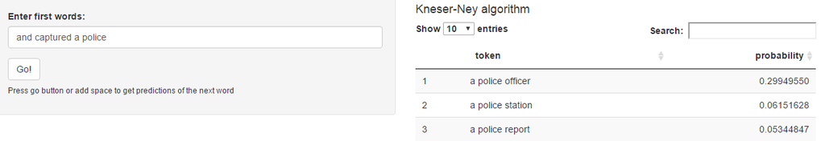

| PerformanceFor | AverageTime | Attemtps | MinMemory |
| --- | --- | --- | --- |
| Kneser-Ney Smoothing | 90 ms | 100 | 118 MB |
| Naive with Good-Turing Smoothing | 420 ms | 100 | 118 MB |

Steps to improve the model:

- Input data are relatively small, it should be at least 10x times bigger.
- We can significantly decrease memory consumption and improve CPU performance by transforming string to compact mode.
- Boosting different type of models.